# Klasteranalüüs k-keskmiste meetodil

Indrek Soidla

25 3 2022

Harjutame klasteranalüüsi Euroopa Sotsiaaluuringu 2016. aasta Eesti andmete põhjal. Eesmärk on leida erinevate rahuloludimensioonide alusel eristuvad grupid elanikkonna seas.

Laeme sisse vajalikud paketid.

```r
library(essurvey)
library(dplyr)
library(descr)
```

Alljärgnevas koodijupis sisestage funktsiooni `set_email` puhul jutumärkide vahele **oma** email, millega olete [Euroopa Sotsiaaluuringu lehel](http://www.europeansocialsurvey.org) registreerunud ESS andmete kasutajaks.

```r
set_email("indrek.soidla@ut.ee")

ee8 <- import_country("Estonia", 8)
```

Eraldame alamandmestiku, kus on rahulolu tunnused ja lisaks mõni taustatunnus.

```r
library(dplyr)
stf <- ee8 %>%
  select(idno, stflife, stfeco, stfgov, stfdem, stfedu, stfhlth, gndr, eduyrs, pspwght)
```

Enne kui klasterdamise juurde asuda, tuleks järgi uurida põhilised tunnuste jaotusparameetrid. Kuna rahulolu tunnused on mõõdetud skaalal nullist kümneni, kus ainult skaala otspunktid on sõnaliselt defineeritud, siis võime eeldada, et vastajad on tajunud skaalapunktide vahesid võrdsetena ja tunnuseid võib käsitleda arvulistena.

```r
psych::describe(stf[2:7])
```

```
##         vars    n mean   sd median trimmed  mad min max range  skew kurtosis
## stflife    1 2019 6.78 2.05      7    6.90 1.48   0  10    10 -0.65     0.26
## stfeco     2 1991 4.92 2.14      5    4.99 2.97   0  10    10 -0.29    -0.35
## stfgov     3 1956 4.08 2.22      4    4.09 2.97   0  10    10 -0.01    -0.54
## stfdem     4 1947 5.08 2.38      5    5.17 2.97   0  10    10 -0.25    -0.48
## stfedu     5 1982 6.59 2.05      7    6.75 1.48   0  10    10 -0.78     0.48
## stfhlth    6 2006 5.00 2.28      5    5.03 2.97   0  10    10 -0.07    -0.55
##           se
## stflife 0.05
## stfeco  0.05
## stfgov  0.05
## stfdem  0.05
## stfedu  0.05
## stfhlth 0.05
```

Mida olulist selle käsuga teada saime? Rahulolu tunnuste keskmised ja mediaanid on üsna sarnased, st suurt ebasümmeetrilisust andmetes ei tohiks olla, asümmeetriakordaja on -0,5 ja -1 vahel kahel tunnusel, teistel nullile lähemal. Mõjukaid erindeid ei ole juba seetõttu, et tunnused on piiratud skaalaga (nullist kümneni). Kvantiilide piirid küll mõnevõrra erinevad, seega hajuvust võiks lisaks kontrollida nt standardhälbe põhjal - see ei erine väga palju, 2,1-st kuni 2,4-ni. Antud tulemus on oluline selle osas, kas tunnuseid tuleks enne klasterdamist standardiseerida. Kõik tunnused on mõõdetud samal skaalal, aga kui mõne tunnuse hajuvus on märkimisväärselt suurem, omandab ta indiviididevaheliste kauguste arvutamisel suurema kaalu. Praegusel juhul võib tunnuseid standardiseerida (nt z-skooride abil), aga tingimata vajalik see ehk ei ole.

Lisaks on näha, et puuduvaid väärtuseid on mõnes tunnuses üksjagu. Kuna k-keskmiste meetodi puhul ei tohi indiviidil klasterduse aluseks olevatest tunnustest üheski puuduvaid väärtuseid esineda, on oluline vaadata, kui suurel osal indiviididest on vähemalt ühes tunnuses puuduv väärtus.

```r
nrow(na.omit(stf))
```

```
## [1] 1873
```

```r
nrow(stf)
```

```
## [1] 2019
```

```r
nrow(na.omit(stf)) / nrow(stf)
```

```
## [1] 0.927687
```

Andmelüngad puuduvad 93% indiviididest, st 7% indiviide jääks praegu analüüsist välja. Sellise protsendi puhul oleks natuke julge eeldada, et lüngad on täiesti juhuslikud, mis on probleem edasises analüüsis saadavate tulemuste populatsioonile üldistamise suhtes. On erinevaid meetodeid, kuidas andmelünki teiste tunnuste kaasabil täita, aga me ei jõua neid selles kursuses käsitleda, seetõttu tuleb lihtsalt andmelünkade osakaal meeles pidada ja seda tulemuste tõlgendamisel meeles pidada. Täpsemaks andmelünkade analüüsiks võib rakendada esimeses loengus õpitut.

Enne klasterdamist seame paika juhuarvugeneraatori

```r
set.seed(20)
```

Teeme kõigepealt lihtsama näite klasterdusest kahe tunnuse alusel, siis on tulemus intuitiivselt lihtsamini mõistetav. Arvutame klastrid k-keskmiste meetodil, võtame kõigepealt klastrite arvuks kolm.

Klasterdusmeetodile ei meeldi puuduvad väärtused tunnustes. Loome kõigepealt uue andmestiku, kust on eemaldatud indiviidid, kellel on mõnes tunnuses andmelünk.

```r
stf_f <- na.omit(stf)
stf_km3 <- kmeans(stf_f[2:3], centers = 3, iter.max = 30)
stf_km3
```

```
## K-means clustering with 3 clusters of sizes 595, 768, 510
##
## Cluster means:
##    stflife   stfeco
## 1 7.465546 3.818487
## 2 8.058594 6.949219
## 3 4.184314 3.254902
##
## Clustering vector:
##    [1] 2 1 2 3 2 2 2 3 1 3 2 1 1 2 1 2 1 1 1 2 3 2 3 2 3 2 3 2 1 2 1 2 3 2 3 2 3
##   [38] 1 2 1 2 1 2 3 1 3 1 1 2 2 1 1 1 1 2 3 1 1 2 1 1 2 1 1 2 3 2 2 2 2 2 2 3 1
##   [75] 2 2 2 3 1 2 3 2 2 1 2 2 1 1 1 2 2 1 3 2 2 2 2 1 2 2 2 1 3 2 2 2 2 2 2 3 2
##  [112] 1 2 2 1 2 3 2 3 2 3 2 1 1 2 1 2 3 1 2 1 3 2 2 2 1 2 3 2 2 1 3 1 2 3 2 2 3
##  [149] 1 2 3 1 3 3 1 3 2 2 3 2 2 3 1 1 2 1 2 2 1 2 1 1 2 2 3 2 2 2 3 1 2 3 2 1 2
##  [186] 2 3 1 2 2 1 1 2 2 1 1 3 3 1 2 1 1 2 2 3 3 1 3 2 1 1 2 3 3 2 2 1 2 2 1 3 2
```

[output cut: 54 more lines]

Saadud tulemused võivad igaühel veidi erineda, sest tsentroidide algpunktid võetakse juhuslikud. Klastrite koosseisud võivad seetõttu olla erinevate klasterduste puhul erisugused, sõltudes tsentroidide algpunktidest. Selle vältimiseks on mõistlik teha mitmeid klasterdusi ja valida neist välja see, kus klastrisiseste ruuthälvete (ehk klastrisse kuuluvate indiviidide vaheliste kauguste ruutude) summa on väikseim. R teeb seda ise, kui lisame funktsioonile kmeans argumendi `nstart`, millele väärtuse omistamisega saame ette anda, mitu klasterdust R kulisside taga läbi viib. Vaikeseadena on argumenti nstart väärtus 1 ehk viiakse läbi ainult üks klasterdus, see väärtus võiks olla suurem.

Lisame argumendi nstart. Kui R hakkab pilduma veateateid ‘Unknown or uninitialised column’, siis neid võib ignoreerida, see on mingi R-i diagnostika kala.

```r
stf_km3 <- kmeans(stf_f[2:3], centers = 3, iter.max = 30, nstart = 25)
stf_km3
```

```
## K-means clustering with 3 clusters of sizes 595, 768, 510
##
## Cluster means:
##    stflife   stfeco
## 1 7.465546 3.818487
## 2 8.058594 6.949219
## 3 4.184314 3.254902
##
## Clustering vector:
##    [1] 2 1 2 3 2 2 2 3 1 3 2 1 1 2 1 2 1 1 1 2 3 2 3 2 3 2 3 2 1 2 1 2 3 2 3 2 3
##   [38] 1 2 1 2 1 2 3 1 3 1 1 2 2 1 1 1 1 2 3 1 1 2 1 1 2 1 1 2 3 2 2 2 2 2 2 3 1
##   [75] 2 2 2 3 1 2 3 2 2 1 2 2 1 1 1 2 2 1 3 2 2 2 2 1 2 2 2 1 3 2 2 2 2 2 2 3 2
##  [112] 1 2 2 1 2 3 2 3 2 3 2 1 1 2 1 2 3 1 2 1 3 2 2 2 1 2 3 2 2 1 3 1 2 3 2 2 3
##  [149] 1 2 3 1 3 3 1 3 2 2 3 2 2 3 1 1 2 1 2 2 1 2 1 1 2 2 3 2 2 2 3 1 2 3 2 1 2
##  [186] 2 3 1 2 2 1 1 2 2 1 1 3 3 1 2 1 1 2 2 3 3 1 3 2 1 1 2 3 3 2 2 1 2 2 1 3 2
```

[output cut: 54 more lines]

Et nstart = 25 annab stabiilsed tulemused, näeme ka sellest, et kui seda käsku mitu korda jooksutame, saame samad (või minimaalselt erinevad) tulemused. Veendume selles ise, arvutades samade seadetega (ja nstart vaikeseadena 1) sada klasterdust, salvestame igaühe kohta lõplikud tsentroidide asukohad ja klastrisiseste ruuthälvete summa.

Enne seda loome tühja andmetabeli ja vektori, kuhu nimetatud näitajaid sisestada.

```r
centers <- data.frame(stflife = double(),
                      stfeco = double())
totwss <- vector()
```

Teeme `for`-tsükli abil 100 klasterdust.

```r
for (i in (1:100)) {
  stf_kma <- kmeans(stf_f[2:3], centers = 3, iter.max = 30)
  centers <- rbind(centers, stf_kma$centers)
  totwss[i] <- stf_kma$tot.withinss
}
```

Teeme tsentroidide hajuvusdiagrammi ja klastrisiseste ruuthälvete summa histogrammi.

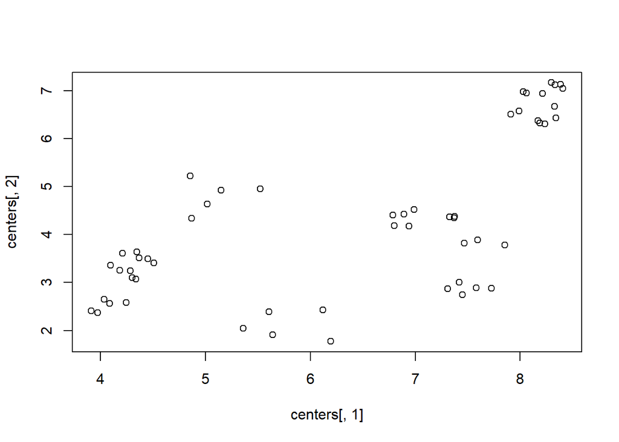

```r
plot(centers[,1], centers[,2])
```

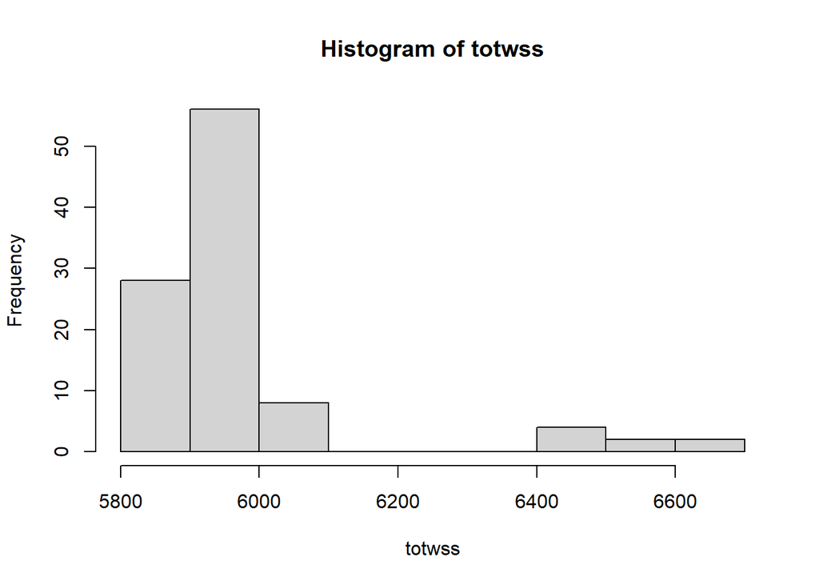

```r
hist(totwss)
```

Teeme sada klasterdust läbi, kui `nstart = 25`. Sisuliselt saame sada klasterdustulemust, millest igaühe puhul on omakorda läbi tehtud 25 klasterdust ja neist valitud parim tulemus (ehk kokku 100 * 25 = 2500 klasterdust).

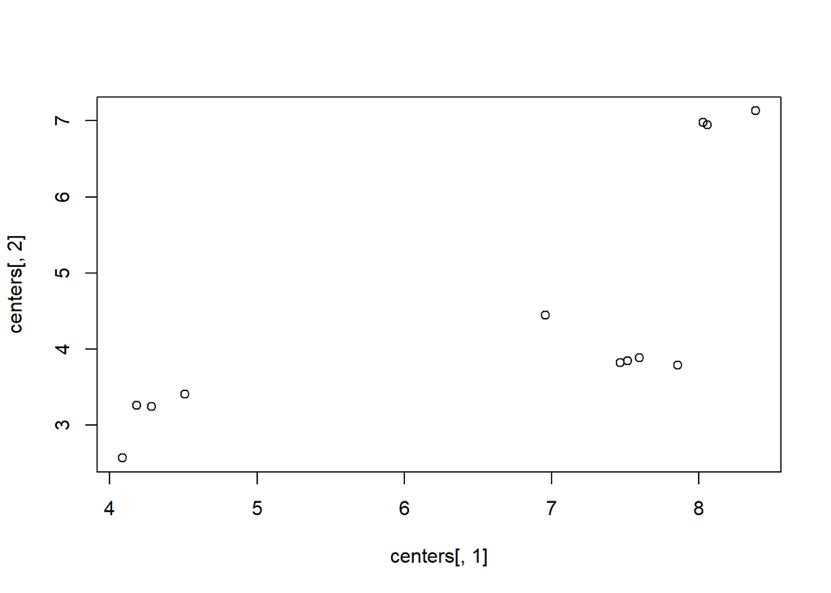

```r
centers <- data.frame(stflife = double(),
                      stfeco = double())
totwss <- vector()

for (i in (1:100)) {
  stf_kma <- kmeans(stf_f[2:3], centers = 3, iter.max = 30, nstart = 25)
  centers <- rbind(centers, stf_kma$centers)
  totwss[i] <- stf_kma$tot.withinss
}

plot(centers[,1], centers[,2])
```

Erinevaid tsentroidide lõpp-punkte on väga vähe, saadud klastrite keskpunktid on stabiilsed.

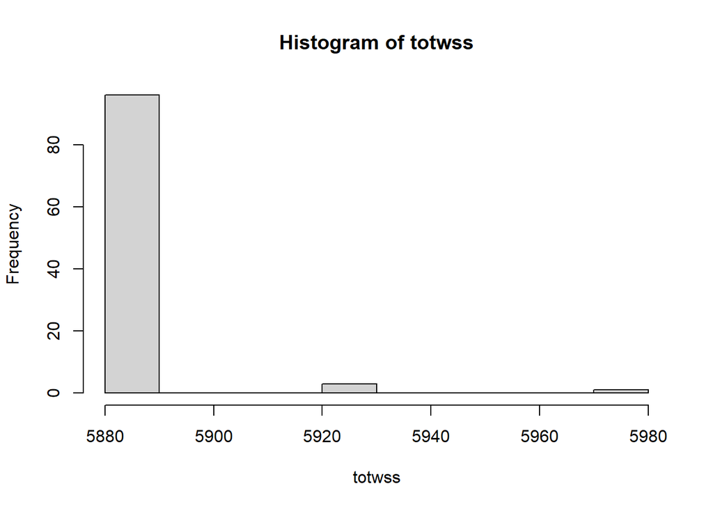

```r
hist(totwss)
```

Praktiliselt kõik klasterdused on sama klastrisiseste kauguste summaga, ainult mõni üksik erineb, kuid väga vähe. Seega on alati mõttekas kasutada argumenti nstart ja seada sellele ühest suurem väärtus. Aga kui suur vähemalt? 25 peaks olema piisav, sellest väiksema väärtuse võiks võtta juhul, kui andmeid on väga palju ja klasterdus võtab palju aega.

Võtame järgnevalt aluseks eelnevalt tehtud klasterduse, kus `nstart = 25` ja vaatame, kuidas klastrid paiknevad klastrite aluseks olevate tunnuste väärtuste lõikes, lisame hajuvusdiagrammile ka klastrite tsentroidid rombidena.

Lisame andmestikku, kus on klasterduse aluseks olnud tunnused, klasterduse tulemuste objektist klastrikuuluvuse tunnuse.

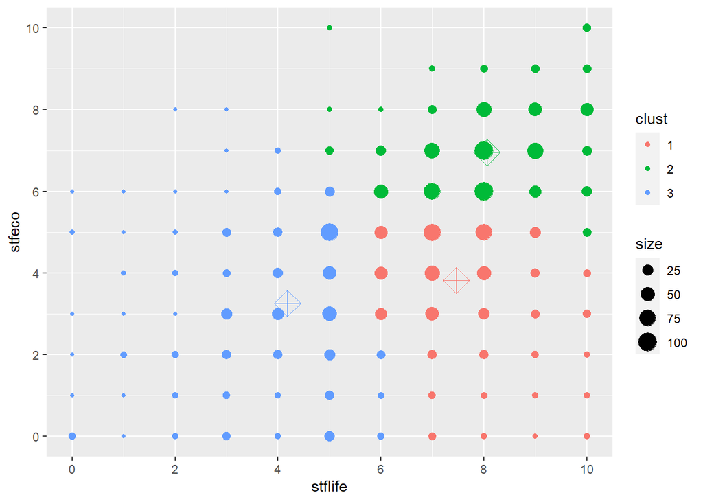

```r
stf_f$clust <- as.factor(stf_km3$cluster)

library(ggplot2)

ggplot(stf_f, aes(x=stflife, y=stfeco, colour = clust)) +
  geom_count() +
  geom_point(data = as.data.frame(stf_km3$centers), aes(x=stflife, y=stfeco, shape = 9, colour = rownames(stf_km3$centers), size = 100)) +
  scale_shape_identity() +
  scale_x_continuous(breaks = seq(0, 10, 2)) +
  scale_y_continuous(breaks = seq(0, 10, 2))
```

Jooniselt on näha, et kuigi kahe tunnuse lõikes ei eristu selgeid gruppe (ei ole ringide kobaraid, pigem ühtlane seos, et mida kõrgem on rahulolu eluga, seda kõrgem on rahulolu majandusega), on klasterduse alusel leitud siiski grupid, mis ei paikne täpselt ühel diagonaalil. Ühes grupis on need, kelle rahulolu on mõlemas dimensioonis üldiselt madal või keskmine, ühes need, kellel üldiselt kumbki rahulolu on kõrge, ja ühes need, kes on küll eluga üldiselt rahul, kuid majanduse olukorraga pigem mitte. Kõige rohkem sisulist huvi võikski pakkuda see viimane grupp - kes nad on teiste tunnuste lõikes ja mis võib olla põhjuseks, et madal rahulolu majandusega ei kajastu rahulolus eluga üldiselt. Siiski võiks enne vaadata, kas kolm klastrit on üleüldse optimaalne jaotus. Meenutame, et k-keskmiste alusel klasterdamise aluseks on klastrisisesed kaugused - mida väiksemad kaugused (ruuthälbed), seda homogeensem on klaster. Saaksime eelpool kasutatud funktsiooniga `kmeans` teha läbi klasterdused erineva arvu klastritega ja arvutada igal juhul klastrisiseste ruuthälvete summa kõigi klastrite peale kokku ning võrrelda saadud tulemusi. Seda saab aga meie eest teha paketis `factoextra` olev käsk, mis teeb tulemuste alusel ka joonise:

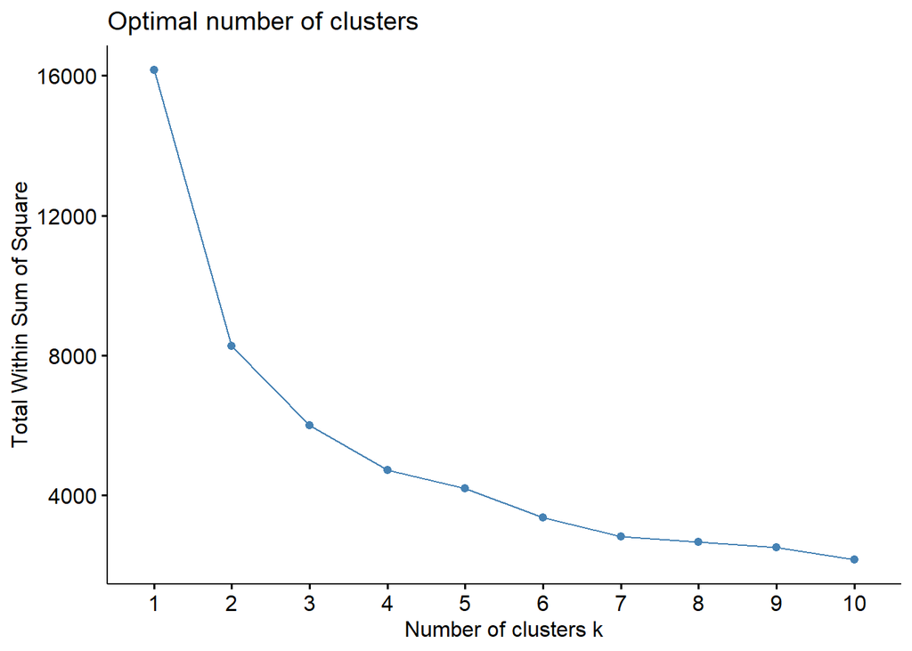

```r
library(factoextra)

fviz_nbclust(stf_f[2:3], kmeans, method = "wss")
```

Joonise alusel tundub, et ruuthälvete summa väheneb alates neljast klastrist juba vähenevas tempos (hinnang on on teatud määral subjektiivne), seega proovime ka neljast klasterdust.

```r
stf_km4 <- kmeans(stf_f[2:3], centers = 4, iter.max = 30, nstart = 25)
stf_km4
```

```
## K-means clustering with 4 clusters of sizes 287, 349, 547, 690
##
## Cluster means:
##    stflife   stfeco
## 1 4.059233 1.867596
## 2 4.931232 5.229226
## 3 7.579525 3.787934
## 4 8.308696 7.008696
##
## Clustering vector:
##    [1] 4 3 4 1 4 4 4 1 3 1 4 3 3 4 3 2 3 3 3 4 2 4 1 4 1 4 1 4 3 4 3 4 1 4 2 2 1
##   [38] 3 4 3 4 3 4 1 3 1 3 3 4 4 3 3 3 3 4 1 3 3 4 3 3 4 3 3 4 2 4 4 4 4 4 4 1 3
##   [75] 4 4 4 2 3 4 2 4 4 3 2 2 3 3 3 4 4 3 1 4 4 4 4 3 4 4 2 3 2 4 4 4 4 4 4 1 2
##  [112] 3 4 4 3 2 1 4 2 4 1 4 2 3 4 3 4 1 2 4 3 2 4 4 4 3 2 2 4 4 3 2 2 4 1 4 2 1
##  [149] 3 4 2 3 1 1 3 1 4 4 1 4 4 2 3 3 4 3 2 4 3 4 3 3 4 2 2 4 2 4 1 3 2 2 4 3 2
```

[output cut: 55 more lines]

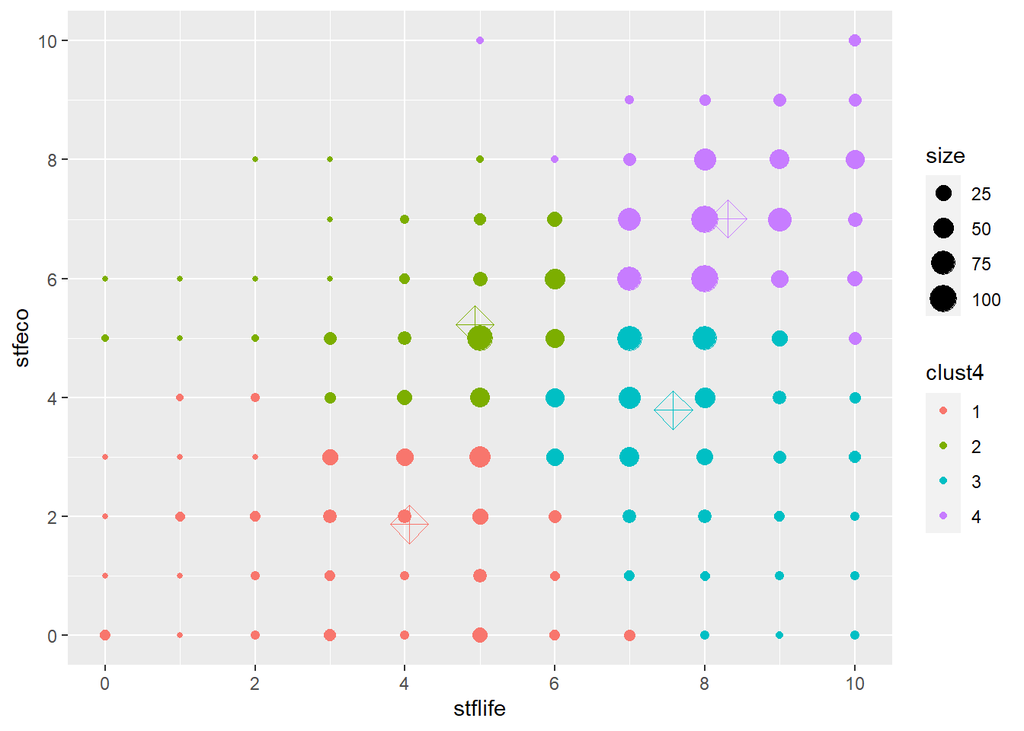

```r
stf_f$clust4 <- as.factor(stf_km4$cluster)

ggplot(stf_f, aes(x=stflife, y=stfeco, colour = clust4)) +
  geom_count() +
  geom_point(data = as.data.frame(stf_km4$centers),
             aes(x=stflife, y=stfeco, shape = 9, colour = rownames(stf_km4$centers), size = 100)) +
  scale_shape_identity() +
  scale_x_continuous(breaks = seq(0, 10, 2)) +
  scale_y_continuous(breaks = seq(0, 10, 2))
```

Nagu jooniselt näha, on klastrite jaotus sisulises plaanis jäänud samaks, lisandunud on üks klaster, kus enamus indiviide on nii majanduse kui üldise rahulolu dimensioonis skaala keskel või majandusega rahul ja eluga üldiselt mitte eriti. Samas ei ole klastrite piirid väga konkreetsed, nt mõlemas dimensioonis rahulolematute hulgas on ka neid, kes eluga on üsna rahul (7), aga majanduse olukorraga üldse mitte (0). Tekib küsimus, kas pole mõttekam ise indiviidid selgepiirilisemalt ära jaotada, nt nii:

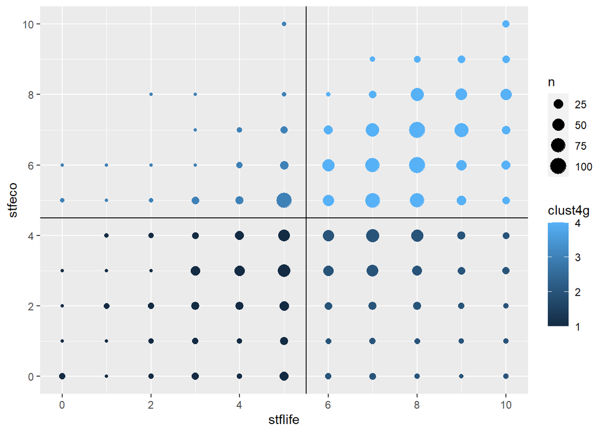

```r
stf_f$clust4g[stf_f$stflife <= 5 & stf_f$stfeco < 5] <- 1
stf_f$clust4g[stf_f$stflife > 5 & stf_f$stfeco < 5] <- 2
stf_f$clust4g[stf_f$stflife <= 5 & stf_f$stfeco >= 5] <- 3
stf_f$clust4g[stf_f$stflife > 5 & stf_f$stfeco >= 5] <- 4

ggplot(stf_f, aes(x = stflife, y = stfeco, colour = clust4g)) +
  geom_count() +
  scale_shape_identity() +
  scale_x_continuous(breaks = seq(0, 10, 2)) +
  scale_y_continuous(breaks = seq(0, 10, 2)) +
  geom_hline(yintercept = 4.5) +
  geom_vline(xintercept = 5.5)
```

Kui kahe tunnuse ühisjaotuses selgesti eristatavaid gruppe ehk kobaraid ei esine (nagu antud näites), siis võib see lähenemine kas või tõlgenduslikult tõesti parem ja lihtsam olla. Küll aga oleks taolist lähenemist keeruline rakendada, kui tunnuseid oleks rohkem kui kaks või kolm, nii et kahemõõtmelisele hajuvusdiagrammile neid asetada ei saaks.

Proovimegi nüüd arvutada klastrid, võttes arvesse indiviididevahelisi kauguseid kõigi kuue rahulolu tunnuse lõikes. Kontrollime ka eelnevalt, kas tunnuste alusel võiks leiduda loomulikke klastreid.

```r
get_clust_tendency(stf_f[2:7], 40, graph = F)
```

```
## $hopkins_stat
## [1] 0.6707452
##
## $plot
## NULL
```

Tulemuseks saame Hopkinsi statistiku, mille väärtus 0,5 või alla selle näitab, et loomulikke klastreid antud tunnuste alusel ei tuvastata. Hopkinsi statistik ei ole siiski probleemideta, ja klasterdus võib omada sisulist tähendust ka juhul, kui andmetes ei esine loomulikke klastreid.

Vaatame, milline oleks sobiv klastrite arv kuue tunnuse puhul.

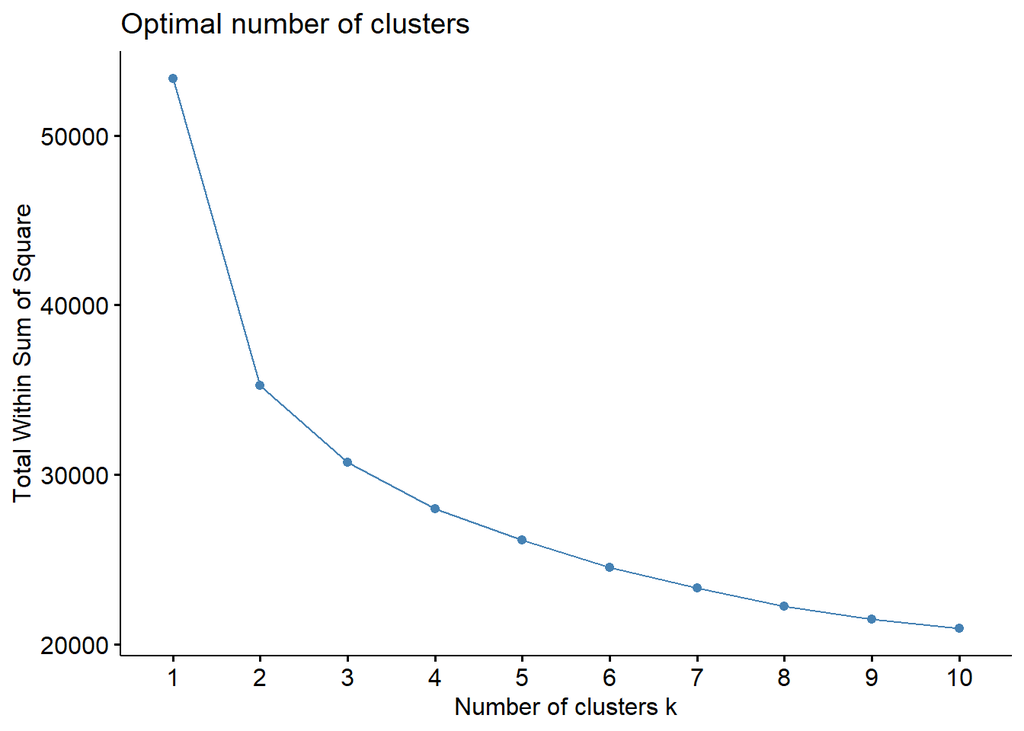

```r
fviz_nbclust(stf_f[2:7], kmeans, method = "wss")
```

Siin selget n-ö küünarnukki või nurka ei teki, võiksime teha nii kolme kui nelja kui viie klastriga, võtame praegu neljase variandi ja teeme klasterduse läbi.

```r
stf_km4v6 <- kmeans(stf_f[2:7], centers = 4, iter.max = 30, nstart = 25)
stf_km4v6
```

```
## K-means clustering with 4 clusters of sizes 463, 480, 395, 535
##
## Cluster means:
##    stflife   stfeco   stfgov   stfdem   stfedu  stfhlth
## 1 6.196544 4.161987 3.142549 4.101512 7.075594 6.079914
## 2 7.202083 5.483333 4.729167 5.827083 6.395833 3.558333
## 3 5.243038 2.632911 1.701266 2.516456 4.397468 2.891139
## 4 8.164486 6.859813 6.052336 7.170093 7.878505 6.884112
##
## Clustering vector:
##    [1] 4 1 4 1 4 4 2 3 4 1 2 4 1 4 1 4 4 2 3 4 2 4 3 4 3 2 3 1 3 4 1 2 3 2 1 4 3
##   [38] 2 2 3 4 1 4 3 1 1 3 1 2 2 2 2 1 1 2 3 1 2 4 3 2 4 3 1 2 1 4 4 4 4 4 2 3 1
##   [75] 2 4 4 1 4 4 1 4 4 3 2 2 3 3 1 4 1 1 3 4 4 4 2 4 4 4 4 1 1 4 1 4 4 4 2 1 2
##  [112] 1 2 4 1 2 1 1 2 2 3 4 1 3 2 2 2 3 4 4 2 1 4 4 4 1 2 3 2 4 4 4 2 4 3 1 2 3
##  [149] 2 4 4 2 3 3 1 3 4 2 3 4 2 1 1 2 4 3 3 4 2 4 4 2 2 1 1 4 4 4 3 2 4 2 1 1 2
```

[output cut: 55 more lines]

Enne sisulisema analüüsi juurde minekut võiks veel uurida, kas kõik tunnused on ühesuguse eristusvõimega klastrite moodustamise seisukohalt. Kas mõni tunnus lisab ainult müra ja oleks mõttekas ta klastrite moodustamisest välja jätta?

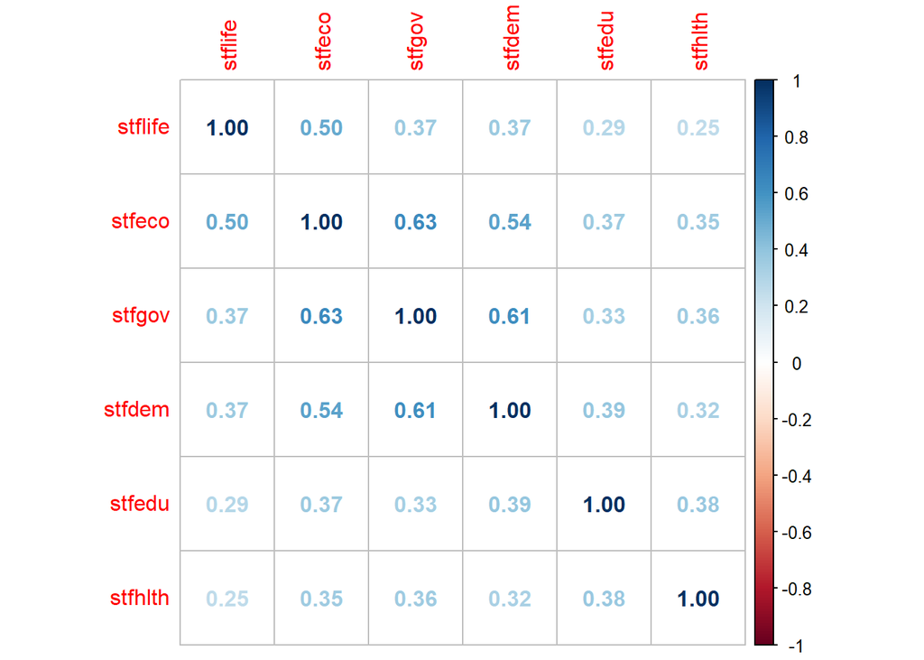

```r
library(corrplot)
corrplot(cor(stf_f[2:7]), method = "number")
```

Kõige tugevamalt on omavahel seotud rahulolu majandusega, valitsusega ja demokraatia olukorraga. Kas mingi neist kolmest tunnusest välja jätta, sõltub eelkõige sisulistest kaalutlustest, st kas nad ka sisu poolest üksteist dubleerivad. Rahulolu valitsusega küll mingil määral kattub demokraatiaga rahul olemisega, aga sisuliselt mõõdavad need kaks kontseptsiooni ikkagi erinevaid asju, seetõttu otsest vajadust tunnuseid välja jätta siin ma ei näe.

Et aimu saada, kuidas eri tüüpi rahulolu poolest sarnased indiviidid (klastrid) erinevad teistest, uurime, milline on klastrite koosseis ehk mille poolest ja kuidas klastrid eristuvad klastrite moodustamise aluseks olnud tunnuste seisukohalt.

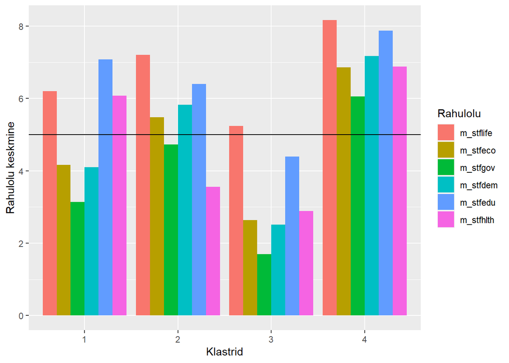

```r
stf_f$clust4v6 <- as.factor(stf_km4v6$cluster)

means <- stf_f %>%
  group_by(clust4v6) %>%
  summarise(
    m_stflife = mean(stflife),
    m_stfeco = mean(stfeco),
    m_stfgov = mean(stfgov),
    m_stfdem = mean(stfdem),
    m_stfedu = mean(stfedu),
    m_stfhlth = mean(stfhlth)
  )

library(reshape2)

means2 <- melt(means, id=c("clust4v6"))

ggplot(means2, aes(x = clust4v6, y = value, group = variable, fill = variable)) +
  geom_bar(stat = "identity", position = "dodge") +
  geom_hline(yintercept = 5) +
  xlab("Klastrid") +
  ylab("Rahulolu keskmine") +
  labs(fill = "Rahulolu")
```

Üldine rahulolu eluga on üle skaala keskpunkti kõigis klastrites, sellegipoolest on kõigil klastritel oma eripära. Selgelt kaks klastrit, kus rahulolu on kõigis dimensioonides madalaim või kõrgeim (NB! Kui teete k-keskmiste klasterduse läbi mitu korda, siis näete, et igal korral klasterduvad ühte klastrisse samad indiviidid, aga klastrite järjekorranumbrid võivad olla iga kord erinevad, seetõttu ei viita ma siinkohal klastreid tõlgendades ka klastrite numbritele). Omapärane ja huvitavam on üks klaster, kus eri dimensioonides on rahulolu gruppide lõikes kolmandal kohal, aga rahulolu haridus- ja tervishoiusüsteemiga on peaaegu kõrgeim. Seega võib öelda, et esineb grupp, kus rahulolu haridus- ja tervishoiusüsteemiga hinnatakse kõrgemalt, hoolimata madalamast rahulolust muudes eluvaldkondades.

Kas klastrid erinevad kuidagi soolise tasakaalu või haridustee pikkuse poolest?

```r
means_ge <- stf_f %>%
  group_by(clust4v6) %>%
  summarise(
    m_gndr = mean(gndr - 1),
    m_eduyrs = mean(eduyrs)
  )
```

Arvutasime siin keskmise soo tunnusest, mis võib tekitada küsimusi - kuidas võiks olla õigustatud nominaaltunnusest keskmise arvutamine? Antud juhul on tegu kaheväärtuselise tunnusega, seega juhul, kui ühe kategooria kood on null ja teise oma üks, siis saame keskmise arvutamisel teise kategooria osakaalu (sisuliselt naiste protsendi kõigist indiviididest).

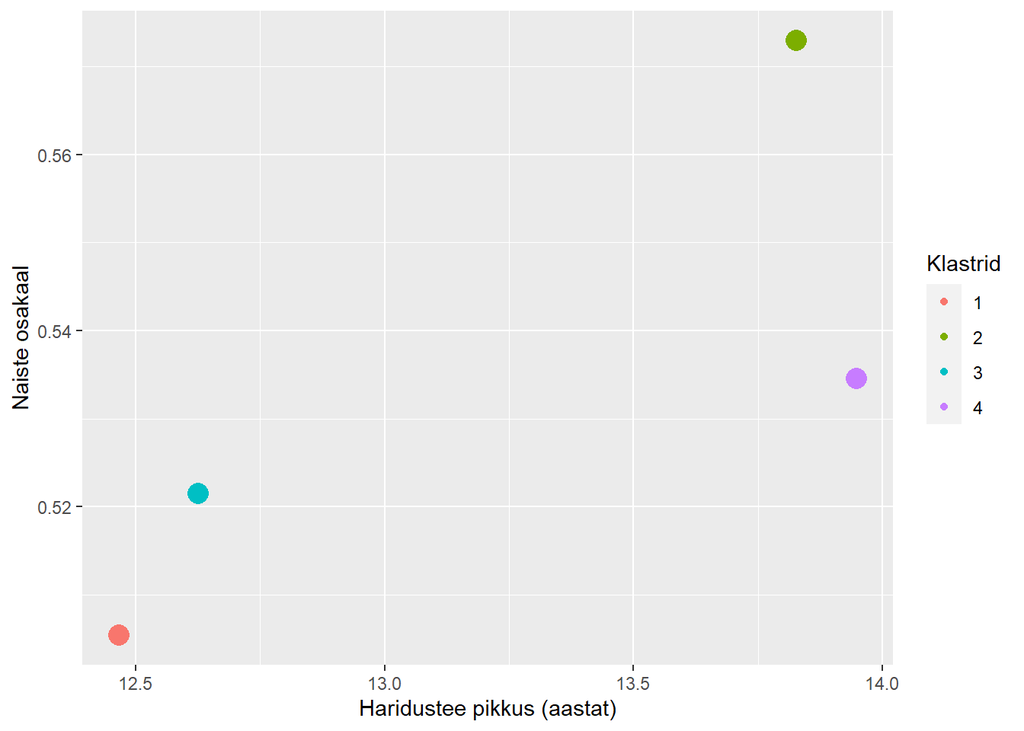

```r
ggplot(means_ge, aes(x = m_eduyrs, y = m_gndr, colour = clust4v6, size = 100)) +
  geom_point() +
  xlab("Haridustee pikkus (aastat)") +
  ylab("Naiste osakaal") +
  labs(colour = "Klastrid") +
  guides(size = "none")
```

Jooniselt näeme, et need klastrid, kus keskmine rahulolu oli enamikus dimensioonides kõrgem, on ka haridustee keskmiselt pikem, ühes neist klastritest on ka naiste osakaal mõnevõrra kõrgem. Need infokillud võivad aidata meil mõtestada sisulisemalt, mis on klastritevahelised erinevused ja mis võib erisuguste indiviidide eri klastritesse paigutumise taga olla. Kui analüüsiksime samamoodi nt oma ettevõtte kliendibaasi, aitaks see meil oma klientuuri, selle struktuuri ja eripärasid paremini mõista.

Kõik eelnev on lihtsuse mõttes läbi tehtud ilma andmeid kaalumata. Andmete kaalumine võib klasterstruktuuri mõnevõrra muuta, kuid ei pruugi (märkimisväärselt) - kuna klasteranalüüs põhineb indiviididevahelistel kaugustel, ei mängi kaalumine niivõrd suurt rolli kui näiteks sagedusjaotuste arvutamisel. Kaalutud andmetega saab k-keskmiste klasterdust teha käsuga `kmeans.weight` paketis `SWKM`, mida saab ainult GitHubi kaudu laadida. See ei pruugi alati töötada, sest vajab töötamiseks ka paketti `Rtools`, mille peab eraldi installeerima. Võib siiski proovida `SWKM`i ilma eraldi `Rtoolsi` alla laadimata; võimalik, et vahepeal pakutakse võimalust erinevaid pakette uuendada/installeerida, sel juhul tuleks valida valik 5 (RccpArmadillo).

```r
library(remotes)
```

```r
remotes::install_github("Van1yu3/SWKM")
```

```r
library(SWKM)
```

Kui R ütleb eelviimase käsu peale `Skipping install of 'SWKM' from a github remote, the SHA1 (b8763db3) has not changed since last install.`

`` Use ``force = TRUE`` to force installation ``,

siis võib proovida veel:

```r
remotes::install_github("Van1yu3/SWKM", force = T)
library(SWKM)
```

Teeme eelnevalt tehtud klasterduse näite rahulolu tunnuste ja kolme klastriga läbi nüüd ka kaalutud andmetega, enne tuleb andmestik muuta maatriksiks nagu `kmeans.weight` nõuab. Järgnevate käskude puhul ei näe te html-failis väljundit ehk käskluste tulemusi, jätsin need välja, sest millegipärast andsid nad html-faili loomisel veateate; samas Rmd-failis käske käima lastes nad minul töötasid, nii et põhimõtteliselt peaks kood töötama.

```r
stf_f <- as.matrix(stf_f)
stf_km3_w <- kmeans.weight(stf_f[, 2:7], K = 3, weight = stf_f[, 10], nstart = 25)
```

Siin on võrdluseks ka eelnevalt tehtud klasterdus kaaludeta.

```r
stf_km3 <- kmeans(stf_f[, 2:7], centers = 3, iter.max = 30, nstart = 25)
```

Võrdleme tulemusi.

```r
stf_f <- as.data.frame(stf_f)
stf_f$clust <- stf_km3$cluster
stf_f$clustwt <- as.integer(stf_km3_w$cluster)
```

Kuivõrd erinevad tulemused saime? Klastrite järjekorranumbrid ei mängi siinkohal rolli, oluline on, kas klastrite lõikes moodustub sarnane struktuur (st tulemused on sarnased, kui lõviosa indiviididest on allolevas risttabelis ainult kolmes grupis üheksast võimalikust).

```r
table(stf_f$clust, stf_f$clustwt)
```

## Mõned harjutused

1. Uurige, kuidas on moodustatud klastrid seotud elukohaga. Elukoht on Euroopa Sotsiaaluuringu andmestikus talletatud ainult NUTS3 tasandil, st terve Eesti peale on viis regiooni, vt https://www.stat.ee/296046. Kas mõnes regioonis on mingi klastri esindajaid rohkem või vähem? Milliseid mõtteid see tekitab rahulolumustrite geograafiliste või etniliste iseärasuste kohta?
2. Klasterduse aluseks olevaid tunnuseid me eelnevalt ei standardiseerinud. Proovige see ise ära teha. Tehke standardiseeritud tunnustega klasterdus uuesti ja uurige, kas tulemus muutus kuidagi. Standardiseerimiseks (z-skooride arvutamiseks) saab kasutada funktsiooni `scale`, sama käsuga mitme tunnuse standardiseerimiseks on abi funktsioonist `apply` (kuigi saab ka ilma selleta).